# Risk Factor Analysis

## Outcome Variable

**Outcome Variable:** haz

## Predictor Variables

**Intervention Variable:** impfloor

**Adjustment Set:**

- arm
- sex
- W_mage
- meducyrs
- feducyrs
- hhwealth_quart
- hfoodsec
- W_mhtcm
- W_mwtkg
- W_mbmi
- W_nrooms
- W_nchldlt5
- W_parity
- impsan
- safeh20
- delta_W_mage
- delta_meducyrs
- delta_feducyrs
- delta_hhwealth_quart
- delta_hfoodsec
- delta_W_mhtcm
- delta_W_mwtkg
- delta_W_mbmi
- delta_W_nrooms
- delta_W_nchldlt5
- delta_W_parity
- delta_impsan
- delta_safeh20

## Stratifying Variables

The analysis was stratified on these variable(s):

- agecat
- studyid
- country

## Data Summary

| agecat | studyid | country | impfloor | n_cell | n |
| --- | --- | --- | --- | --- | --- |
| Birth | ki0047075b-MAL-ED | BANGLADESH | 1 | 196 | 213 |
| Birth | ki0047075b-MAL-ED | BANGLADESH | 0 | 17 | 213 |
| Birth | ki0047075b-MAL-ED | BRAZIL | 1 | 58 | 60 |
| Birth | ki0047075b-MAL-ED | BRAZIL | 0 | 2 | 60 |
| Birth | ki0047075b-MAL-ED | INDIA | 1 | 35 | 41 |
| Birth | ki0047075b-MAL-ED | INDIA | 0 | 6 | 41 |
| Birth | ki0047075b-MAL-ED | NEPAL | 1 | 9 | 25 |
| Birth | ki0047075b-MAL-ED | NEPAL | 0 | 16 | 25 |
| Birth | ki0047075b-MAL-ED | PERU | 1 | 39 | 215 |
| Birth | ki0047075b-MAL-ED | PERU | 0 | 176 | 215 |
| Birth | ki0047075b-MAL-ED | SOUTH AFRICA | 1 | 87 | 96 |
| Birth | ki0047075b-MAL-ED | SOUTH AFRICA | 0 | 9 | 96 |
| Birth | ki0047075b-MAL-ED | TANZANIA, UNITED REPUBLIC OF | 1 | 7 | 119 |
| Birth | ki0047075b-MAL-ED | TANZANIA, UNITED REPUBLIC OF | 0 | 112 | 119 |
| Birth | ki1000108-CMC-V-BCS-2002 | INDIA | 1 | 72 | 72 |
| Birth | ki1000108-CMC-V-BCS-2002 | INDIA | 0 | 0 | 72 |
| Birth | ki1000108-IRC | INDIA | 1 | 287 | 287 |
| Birth | ki1000108-IRC | INDIA | 0 | 0 | 287 |
| Birth | ki1017093-NIH-Birth | BANGLADESH | 1 | 533 | 605 |
| Birth | ki1017093-NIH-Birth | BANGLADESH | 0 | 72 | 605 |
| Birth | ki1017093b-PROVIDE | BANGLADESH | 1 | 491 | 539 |
| Birth | ki1017093b-PROVIDE | BANGLADESH | 0 | 48 | 539 |
| Birth | ki1017093c-NIH-Crypto | BANGLADESH | 1 | 558 | 732 |
| Birth | ki1017093c-NIH-Crypto | BANGLADESH | 0 | 174 | 732 |
| Birth | ki1113344-GMS-Nepal | NEPAL | 1 | 100 | 544 |
| Birth | ki1113344-GMS-Nepal | NEPAL | 0 | 444 | 544 |
| Birth | ki1114097-CONTENT | PERU | 1 | 2 | 2 |
| Birth | ki1114097-CONTENT | PERU | 0 | 0 | 2 |
| Birth | kiGH5241-JiVitA-3 | BANGLADESH | 1 | 2064 | 26604 |
| Birth | kiGH5241-JiVitA-3 | BANGLADESH | 0 | 24540 | 26604 |

[output cut: 66 more lines]

The following strata were considered:

- agecat: 24 months, studyid: ki0047075b-MAL-ED, country: BANGLADESH
- agecat: 24 months, studyid: ki0047075b-MAL-ED, country: BRAZIL
- agecat: 24 months, studyid: ki0047075b-MAL-ED, country: INDIA
- agecat: 24 months, studyid: ki0047075b-MAL-ED, country: NEPAL
- agecat: 24 months, studyid: ki0047075b-MAL-ED, country: PERU
- agecat: 24 months, studyid: ki0047075b-MAL-ED, country: SOUTH AFRICA
- agecat: 24 months, studyid: ki0047075b-MAL-ED, country: TANZANIA, UNITED REPUBLIC OF
- agecat: 24 months, studyid: ki1000108-CMC-V-BCS-2002, country: INDIA
- agecat: 24 months, studyid: ki1000108-IRC, country: INDIA
- agecat: 24 months, studyid: ki1017093-NIH-Birth, country: BANGLADESH
- agecat: 24 months, studyid: ki1017093b-PROVIDE, country: BANGLADESH
- agecat: 24 months, studyid: ki1017093c-NIH-Crypto, country: BANGLADESH
- agecat: 24 months, studyid: ki1113344-GMS-Nepal, country: NEPAL
- agecat: 24 months, studyid: ki1114097-CONTENT, country: PERU
- agecat: 24 months, studyid: kiGH5241-JiVitA-3, country: BANGLADESH
- agecat: 24 months, studyid: kiGH5241-JiVitA-4, country: BANGLADESH
- agecat: 6 months, studyid: ki0047075b-MAL-ED, country: BANGLADESH
- agecat: 6 months, studyid: ki0047075b-MAL-ED, country: BRAZIL
- agecat: 6 months, studyid: ki0047075b-MAL-ED, country: INDIA
- agecat: 6 months, studyid: ki0047075b-MAL-ED, country: NEPAL
- agecat: 6 months, studyid: ki0047075b-MAL-ED, country: PERU
- agecat: 6 months, studyid: ki0047075b-MAL-ED, country: SOUTH AFRICA
- agecat: 6 months, studyid: ki0047075b-MAL-ED, country: TANZANIA, UNITED REPUBLIC OF
- agecat: 6 months, studyid: ki1000108-CMC-V-BCS-2002, country: INDIA
- agecat: 6 months, studyid: ki1000108-IRC, country: INDIA
- agecat: 6 months, studyid: ki1017093-NIH-Birth, country: BANGLADESH
- agecat: 6 months, studyid: ki1017093b-PROVIDE, country: BANGLADESH
- agecat: 6 months, studyid: ki1017093c-NIH-Crypto, country: BANGLADESH
- agecat: 6 months, studyid: ki1113344-GMS-Nepal, country: NEPAL
- agecat: 6 months, studyid: ki1114097-CONTENT, country: PERU
- agecat: 6 months, studyid: kiGH5241-JiVitA-3, country: BANGLADESH
- agecat: 6 months, studyid: kiGH5241-JiVitA-4, country: BANGLADESH
- agecat: Birth, studyid: ki0047075b-MAL-ED, country: BANGLADESH
- agecat: Birth, studyid: ki0047075b-MAL-ED, country: BRAZIL
- agecat: Birth, studyid: ki0047075b-MAL-ED, country: INDIA
- agecat: Birth, studyid: ki0047075b-MAL-ED, country: NEPAL
- agecat: Birth, studyid: ki0047075b-MAL-ED, country: PERU
- agecat: Birth, studyid: ki0047075b-MAL-ED, country: SOUTH AFRICA
- agecat: Birth, studyid: ki0047075b-MAL-ED, country: TANZANIA, UNITED REPUBLIC OF
- agecat: Birth, studyid: ki1000108-CMC-V-BCS-2002, country: INDIA
- agecat: Birth, studyid: ki1000108-IRC, country: INDIA
- agecat: Birth, studyid: ki1017093-NIH-Birth, country: BANGLADESH
- agecat: Birth, studyid: ki1017093b-PROVIDE, country: BANGLADESH
- agecat: Birth, studyid: ki1017093c-NIH-Crypto, country: BANGLADESH
- agecat: Birth, studyid: ki1113344-GMS-Nepal, country: NEPAL
- agecat: Birth, studyid: ki1114097-CONTENT, country: PERU
- agecat: Birth, studyid: kiGH5241-JiVitA-3, country: BANGLADESH
- agecat: Birth, studyid: kiGH5241-JiVitA-4, country: BANGLADESH

### Dropped Strata

Some strata were dropped due to rare outcomes:

- agecat: Birth, studyid: ki0047075b-MAL-ED, country: BRAZIL
- agecat: Birth, studyid: ki1000108-CMC-V-BCS-2002, country: INDIA
- agecat: Birth, studyid: ki1000108-IRC, country: INDIA
- agecat: Birth, studyid: ki1114097-CONTENT, country: PERU
- agecat: 6 months, studyid: ki0047075b-MAL-ED, country: BRAZIL
- agecat: 6 months, studyid: ki1000108-CMC-V-BCS-2002, country: INDIA
- agecat: 6 months, studyid: ki1000108-IRC, country: INDIA
- agecat: 24 months, studyid: ki0047075b-MAL-ED, country: BRAZIL
- agecat: 24 months, studyid: ki1000108-CMC-V-BCS-2002, country: INDIA
- agecat: 24 months, studyid: ki1000108-IRC, country: INDIA

## Methods Detail

We’re interested in the causal parameters $E[Y_a]$ for all values of $a \in \mathcal{A}$. These parameters represent the mean outcome if, possibly contrary to fact, we intervened to set all units to have $A=a$. Under the randomization and positivity assumptions, these are identified by the statistical parameters $\psi_a=E_W[E_{Y|A,W}(Y|A=a,W)]$. In addition, we’re interested in the mean of $Y$, $E[Y]$ under no intervention (the observed mean). We will estimate these parameters by using SuperLearner to fit the relevant likelihood factors – $E_{Y|A,W}(Y|A=a,W)$ and $p(A=a|W)$, and then updating our likelihood fit using a joint TMLE.

For unadjusted analyses ($W=\{\}$), initial likelihoods were estimated using Lrnr_glm to estimate the simple $E(Y|A)$ and Lrnr_mean to estimate $p(A)$. For adjusted analyses, a small library containing Lrnr_glmnet, Lrnr_xgboost, and Lrnr_mean was used.

Having estimated these parameters, we will then use the delta method to estimate relative risks and attributable risks relative to a prespecified baseline level of $A$.

# Results Detail

## Results Plots

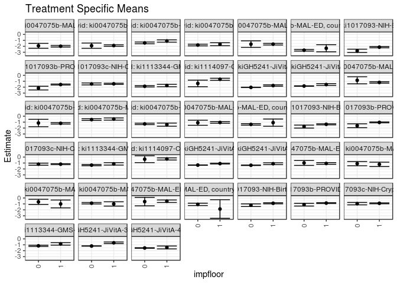

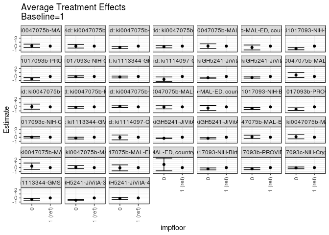

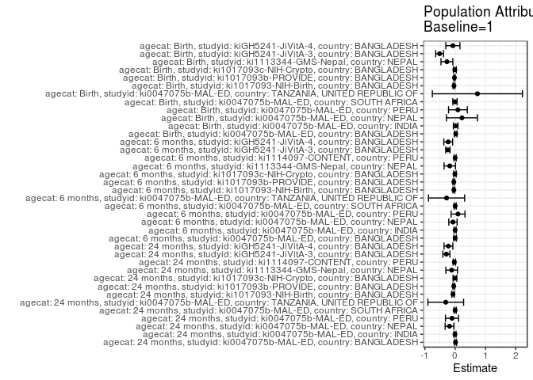

## Results Table

### Parameter: TSM

| agecat | studyid | country | intervention_level | baseline_level | estimate | ci_lower | ci_upper |
| --- | --- | --- | --- | --- | --- | --- | --- |
| Birth | ki0047075b-MAL-ED | BANGLADESH | 1 | NA | -1.0739815 | -1.2166901 | -0.9312729 |
| Birth | ki0047075b-MAL-ED | BANGLADESH | 0 | NA | -0.9879980 | -1.3993246 | -0.5766715 |
| Birth | ki0047075b-MAL-ED | INDIA | 1 | NA | -1.2242857 | -1.5919558 | -0.8566156 |
| Birth | ki0047075b-MAL-ED | INDIA | 0 | NA | -1.1066667 | -1.4622060 | -0.7511274 |
| Birth | ki0047075b-MAL-ED | NEPAL | 1 | NA | -1.0066667 | -1.6704675 | -0.3428658 |
| Birth | ki0047075b-MAL-ED | NEPAL | 0 | NA | -0.6568750 | -1.0897018 | -0.2240482 |
| Birth | ki0047075b-MAL-ED | PERU | 1 | NA | -1.0063134 | -1.3659725 | -0.6466544 |
| Birth | ki0047075b-MAL-ED | PERU | 0 | NA | -0.8811309 | -1.0026305 | -0.7596314 |
| Birth | ki0047075b-MAL-ED | SOUTH AFRICA | 1 | NA | -0.5463218 | -0.7573107 | -0.3353330 |
| Birth | ki0047075b-MAL-ED | SOUTH AFRICA | 0 | NA | -0.6111111 | -1.3247632 | 0.1025410 |
| Birth | ki0047075b-MAL-ED | TANZANIA, UNITED REPUBLIC OF | 1 | NA | -1.8571429 | -3.4252117 | -0.2890740 |
| Birth | ki0047075b-MAL-ED | TANZANIA, UNITED REPUBLIC OF | 0 | NA | -1.0753571 | -1.2760805 | -0.8746338 |
| Birth | ki1017093-NIH-Birth | BANGLADESH | 1 | NA | -0.8907627 | -0.9857669 | -0.7957586 |
| Birth | ki1017093-NIH-Birth | BANGLADESH | 0 | NA | -1.2180656 | -1.4420864 | -0.9940449 |
| Birth | ki1017093b-PROVIDE | BANGLADESH | 1 | NA | -0.8617209 | -0.9408417 | -0.7826001 |
| Birth | ki1017093b-PROVIDE | BANGLADESH | 0 | NA | -1.1266023 | -1.3593933 | -0.8938112 |
| Birth | ki1017093c-NIH-Crypto | BANGLADESH | 1 | NA | -0.8991551 | -0.9787932 | -0.8195171 |
| Birth | ki1017093c-NIH-Crypto | BANGLADESH | 0 | NA | -0.9607495 | -1.1644600 | -0.7570390 |
| Birth | ki1113344-GMS-Nepal | NEPAL | 1 | NA | -0.8465967 | -1.0542220 | -0.6389715 |
| Birth | ki1113344-GMS-Nepal | NEPAL | 0 | NA | -1.1697863 | -1.2709448 | -1.0686278 |
| Birth | kiGH5241-JiVitA-3 | BANGLADESH | 1 | NA | -0.6590000 | -0.7938692 | -0.5241308 |
| Birth | kiGH5241-JiVitA-3 | BANGLADESH | 0 | NA | -1.2055347 | -1.2329960 | -1.1780734 |
| Birth | kiGH5241-JiVitA-4 | BANGLADESH | 1 | NA | -1.4482610 | -1.6922714 | -1.2042505 |
| Birth | kiGH5241-JiVitA-4 | BANGLADESH | 0 | NA | -1.5374804 | -1.5899333 | -1.4850274 |
| 6 months | ki0047075b-MAL-ED | BANGLADESH | 1 | NA | -1.2016270 | -1.3206886 | -1.0825653 |
| 6 months | ki0047075b-MAL-ED | BANGLADESH | 0 | NA | -0.8445171 | -1.4387333 | -0.2503009 |
| 6 months | ki0047075b-MAL-ED | INDIA | 1 | NA | -1.2059729 | -1.3273635 | -1.0845822 |
| 6 months | ki0047075b-MAL-ED | INDIA | 0 | NA | -1.1489251 | -1.7724385 | -0.5254118 |
| 6 months | ki0047075b-MAL-ED | NEPAL | 1 | NA | -0.4804342 | -0.6648363 | -0.2960320 |
| 6 months | ki0047075b-MAL-ED | NEPAL | 0 | NA | -0.5749910 | -0.7192183 | -0.4307636 |
| 6 months | ki0047075b-MAL-ED | PERU | 1 | NA | -1.4247863 | -1.6894388 | -1.1601338 |
| 6 months | ki0047075b-MAL-ED | PERU | 0 | NA | -1.3004080 | -1.4192251 | -1.1815909 |
| 6 months | ki0047075b-MAL-ED | SOUTH AFRICA | 1 | NA | -1.0562920 | -1.1928457 | -0.9197383 |
| 6 months | ki0047075b-MAL-ED | SOUTH AFRICA | 0 | NA | -1.1066619 | -1.5342201 | -0.6791037 |
| 6 months | ki0047075b-MAL-ED | TANZANIA, UNITED REPUBLIC OF | 1 | NA | -1.0871411 | -1.6986461 | -0.4756361 |
| 6 months | ki0047075b-MAL-ED | TANZANIA, UNITED REPUBLIC OF | 0 | NA | -1.3849628 | -1.5119006 | -1.2580250 |
| 6 months | ki1017093-NIH-Birth | BANGLADESH | 1 | NA | -1.3641302 | -1.4580976 | -1.2701628 |
| 6 months | ki1017093-NIH-Birth | BANGLADESH | 0 | NA | -1.7526472 | -2.0058513 | -1.4994431 |
| 6 months | ki1017093b-PROVIDE | BANGLADESH | 1 | NA | -1.0482063 | -1.1230873 | -0.9733252 |
| 6 months | ki1017093b-PROVIDE | BANGLADESH | 0 | NA | -1.6090484 | -1.9328940 | -1.2852027 |
| 6 months | ki1017093c-NIH-Crypto | BANGLADESH | 1 | NA | -1.1922988 | -1.2731339 | -1.1114638 |
| 6 months | ki1017093c-NIH-Crypto | BANGLADESH | 0 | NA | -1.1925612 | -1.3673378 | -1.0177846 |
| 6 months | ki1113344-GMS-Nepal | NEPAL | 1 | NA | -1.1447785 | -1.3464908 | -0.9430661 |
| 6 months | ki1113344-GMS-Nepal | NEPAL | 0 | NA | -1.3582145 | -1.4609001 | -1.2555289 |
| 6 months | ki1114097-CONTENT | PERU | 1 | NA | -0.3131593 | -0.4945218 | -0.1317969 |
| 6 months | ki1114097-CONTENT | PERU | 0 | NA | -0.3582476 | -0.9363299 | 0.2198348 |
| 6 months | kiGH5241-JiVitA-3 | BANGLADESH | 1 | NA | -1.0951896 | -1.1659996 | -1.0243795 |
| 6 months | kiGH5241-JiVitA-3 | BANGLADESH | 0 | NA | -1.3521440 | -1.3758684 | -1.3284196 |
| 6 months | kiGH5241-JiVitA-4 | BANGLADESH | 1 | NA | -1.1158575 | -1.2696352 | -0.9620799 |
| 6 months | kiGH5241-JiVitA-4 | BANGLADESH | 0 | NA | -1.3789412 | -1.4188698 | -1.3390127 |
| 24 months | ki0047075b-MAL-ED | BANGLADESH | 1 | NA | -1.9911229 | -2.1241947 | -1.8580510 |
| 24 months | ki0047075b-MAL-ED | BANGLADESH | 0 | NA | -1.9183478 | -2.3286864 | -1.5080092 |
| 24 months | ki0047075b-MAL-ED | INDIA | 1 | NA | -1.8796903 | -2.0077375 | -1.7516430 |
| 24 months | ki0047075b-MAL-ED | INDIA | 0 | NA | -1.8980550 | -2.3380810 | -1.4580289 |
| 24 months | ki0047075b-MAL-ED | NEPAL | 1 | NA | -1.1113357 | -1.3080836 | -0.9145877 |
| 24 months | ki0047075b-MAL-ED | NEPAL | 0 | NA | -1.4367006 | -1.5855456 | -1.2878556 |
| 24 months | ki0047075b-MAL-ED | PERU | 1 | NA | -1.6504924 | -1.9022660 | -1.3987188 |
| 24 months | ki0047075b-MAL-ED | PERU | 0 | NA | -1.7924277 | -1.9280909 | -1.6567644 |
| 24 months | ki0047075b-MAL-ED | SOUTH AFRICA | 1 | NA | -1.6490134 | -1.7903937 | -1.5076331 |
| 24 months | ki0047075b-MAL-ED | SOUTH AFRICA | 0 | NA | -1.6422398 | -2.1941249 | -1.0903547 |
| 24 months | ki0047075b-MAL-ED | TANZANIA, UNITED REPUBLIC OF | 1 | NA | -2.3327693 | -2.9326365 | -1.7329021 |
| 24 months | ki0047075b-MAL-ED | TANZANIA, UNITED REPUBLIC OF | 0 | NA | -2.6639979 | -2.8051409 | -2.5228549 |
| 24 months | ki1017093-NIH-Birth | BANGLADESH | 1 | NA | -2.1518026 | -2.2597266 | -2.0438786 |
| 24 months | ki1017093-NIH-Birth | BANGLADESH | 0 | NA | -2.7675912 | -3.0436557 | -2.4915266 |
| 24 months | ki1017093b-PROVIDE | BANGLADESH | 1 | NA | -1.5572068 | -1.6424474 | -1.4719662 |
| 24 months | ki1017093b-PROVIDE | BANGLADESH | 0 | NA | -2.1571822 | -2.4707220 | -1.8436424 |
| 24 months | ki1017093c-NIH-Crypto | BANGLADESH | 1 | NA | -1.4347436 | -1.5389816 | -1.3305057 |
| 24 months | ki1017093c-NIH-Crypto | BANGLADESH | 0 | NA | -1.4565215 | -1.6217968 | -1.2912462 |
| 24 months | ki1113344-GMS-Nepal | NEPAL | 1 | NA | -1.7243608 | -1.9253840 | -1.5233376 |
| 24 months | ki1113344-GMS-Nepal | NEPAL | 0 | NA | -1.8559873 | -1.9660326 | -1.7459420 |
| 24 months | ki1114097-CONTENT | PERU | 1 | NA | -0.6704160 | -0.8478667 | -0.4929653 |
| 24 months | ki1114097-CONTENT | PERU | 0 | NA | -1.3738766 | -1.9303273 | -0.8174259 |
| 24 months | kiGH5241-JiVitA-3 | BANGLADESH | 1 | NA | -1.7300054 | -1.8475523 | -1.6124585 |
| 24 months | kiGH5241-JiVitA-3 | BANGLADESH | 0 | NA | -2.0379974 | -2.0669036 | -2.0090913 |
| 24 months | kiGH5241-JiVitA-4 | BANGLADESH | 1 | NA | -1.5592476 | -1.7119855 | -1.4065096 |
| 24 months | kiGH5241-JiVitA-4 | BANGLADESH | 0 | NA | -1.8098377 | -1.8473091 | -1.7723663 |

### Parameter: E(Y)

| agecat | studyid | country | intervention_level | baseline_level | estimate | ci_lower | ci_upper |
| --- | --- | --- | --- | --- | --- | --- | --- |
| Birth | ki0047075b-MAL-ED | BANGLADESH | NA | NA | -1.0530516 | -1.1896058 | -0.9164975 |
| Birth | ki0047075b-MAL-ED | INDIA | NA | NA | -1.2070732 | -1.5254820 | -0.8886644 |
| Birth | ki0047075b-MAL-ED | NEPAL | NA | NA | -0.7828000 | -1.1547571 | -0.4108429 |
| Birth | ki0047075b-MAL-ED | PERU | NA | NA | -0.9141395 | -1.0364098 | -0.7918693 |
| Birth | ki0047075b-MAL-ED | SOUTH AFRICA | NA | NA | -0.5523958 | -0.7550074 | -0.3497843 |
| Birth | ki0047075b-MAL-ED | TANZANIA, UNITED REPUBLIC OF | NA | NA | -1.1213445 | -1.3341800 | -0.9085090 |
| Birth | ki1017093-NIH-Birth | BANGLADESH | NA | NA | -0.9289256 | -1.0178691 | -0.8399821 |
| Birth | ki1017093b-PROVIDE | BANGLADESH | NA | NA | -0.8851020 | -0.9601332 | -0.8100709 |
| Birth | ki1017093c-NIH-Crypto | BANGLADESH | NA | NA | -0.9094945 | -0.9809370 | -0.8380521 |
| Birth | ki1113344-GMS-Nepal | NEPAL | NA | NA | -1.1177022 | -1.2075344 | -1.0278700 |
| Birth | kiGH5241-JiVitA-3 | BANGLADESH | NA | NA | -1.1725229 | -1.2005540 | -1.1444918 |
| Birth | kiGH5241-JiVitA-4 | BANGLADESH | NA | NA | -1.5236135 | -1.5727559 | -1.4744711 |
| 6 months | ki0047075b-MAL-ED | BANGLADESH | NA | NA | -1.2031806 | -1.3209873 | -1.0853738 |
| 6 months | ki0047075b-MAL-ED | INDIA | NA | NA | -1.2069078 | -1.3255669 | -1.0882487 |
| 6 months | ki0047075b-MAL-ED | NEPAL | NA | NA | -0.5534934 | -0.6683107 | -0.4386762 |
| 6 months | ki0047075b-MAL-ED | PERU | NA | NA | -1.3293333 | -1.4383829 | -1.2202838 |
| 6 months | ki0047075b-MAL-ED | SOUTH AFRICA | NA | NA | -1.0554016 | -1.1850591 | -0.9257441 |
| 6 months | ki0047075b-MAL-ED | TANZANIA, UNITED REPUBLIC OF | NA | NA | -1.3700408 | -1.4930436 | -1.2470380 |
| 6 months | ki1017093-NIH-Birth | BANGLADESH | NA | NA | -1.4060639 | -1.4948910 | -1.3172368 |
| 6 months | ki1017093b-PROVIDE | BANGLADESH | NA | NA | -1.0916915 | -1.1661176 | -1.0172654 |
| 6 months | ki1017093c-NIH-Crypto | BANGLADESH | NA | NA | -1.1986783 | -1.2700937 | -1.1272630 |
| 6 months | ki1113344-GMS-Nepal | NEPAL | NA | NA | -1.3225094 | -1.4115793 | -1.2334396 |
| 6 months | ki1114097-CONTENT | PERU | NA | NA | -0.3139217 | -0.4868486 | -0.1409948 |
| 6 months | kiGH5241-JiVitA-3 | BANGLADESH | NA | NA | -1.3358555 | -1.3589365 | -1.3127744 |
| 6 months | kiGH5241-JiVitA-4 | BANGLADESH | NA | NA | -1.3440174 | -1.3812821 | -1.3067527 |
| 24 months | ki0047075b-MAL-ED | BANGLADESH | NA | NA | -1.9789151 | -2.1055330 | -1.8522972 |
| 24 months | ki0047075b-MAL-ED | INDIA | NA | NA | -1.8848458 | -2.0096941 | -1.7599975 |
| 24 months | ki0047075b-MAL-ED | NEPAL | NA | NA | -1.2972172 | -1.4192878 | -1.1751466 |
| 24 months | ki0047075b-MAL-ED | PERU | NA | NA | -1.7544776 | -1.8753255 | -1.6336298 |
| 24 months | ki0047075b-MAL-ED | SOUTH AFRICA | NA | NA | -1.6491807 | -1.7842885 | -1.5140729 |
| 24 months | ki0047075b-MAL-ED | TANZANIA, UNITED REPUBLIC OF | NA | NA | -2.6428302 | -2.7790815 | -2.5065788 |
| 24 months | ki1017093-NIH-Birth | BANGLADESH | NA | NA | -2.2235968 | -2.3265592 | -2.1206344 |
| 24 months | ki1017093b-PROVIDE | BANGLADESH | NA | NA | -1.6024221 | -1.6857420 | -1.5191023 |
| 24 months | ki1017093c-NIH-Crypto | BANGLADESH | NA | NA | -1.4412646 | -1.5249156 | -1.3576135 |
| 24 months | ki1113344-GMS-Nepal | NEPAL | NA | NA | -1.8396747 | -1.9349390 | -1.7444104 |
| 24 months | ki1114097-CONTENT | PERU | NA | NA | -0.6962195 | -0.8674103 | -0.5250287 |
| 24 months | kiGH5241-JiVitA-3 | BANGLADESH | NA | NA | -2.0193889 | -2.0469721 | -1.9918057 |
| 24 months | kiGH5241-JiVitA-4 | BANGLADESH | NA | NA | -1.7804046 | -1.8159135 | -1.7448956 |

### Parameter: ATE

| agecat | studyid | country | intervention_level | baseline_level | estimate | ci_lower | ci_upper |
| --- | --- | --- | --- | --- | --- | --- | --- |
| Birth | ki0047075b-MAL-ED | BANGLADESH | 1 | 1 | 0.0000000 | 0.0000000 | 0.0000000 |
| Birth | ki0047075b-MAL-ED | BANGLADESH | 0 | 1 | 0.0859835 | -0.3484423 | 0.5204092 |
| Birth | ki0047075b-MAL-ED | INDIA | 1 | 1 | 0.0000000 | 0.0000000 | 0.0000000 |
| Birth | ki0047075b-MAL-ED | INDIA | 0 | 1 | 0.1176190 | -0.3938392 | 0.6290772 |
| Birth | ki0047075b-MAL-ED | NEPAL | 1 | 1 | 0.0000000 | 0.0000000 | 0.0000000 |
| Birth | ki0047075b-MAL-ED | NEPAL | 0 | 1 | 0.3497917 | -0.4426543 | 1.1422376 |
| Birth | ki0047075b-MAL-ED | PERU | 1 | 1 | 0.0000000 | 0.0000000 | 0.0000000 |
| Birth | ki0047075b-MAL-ED | PERU | 0 | 1 | 0.1251825 | -0.2524783 | 0.5028433 |
| Birth | ki0047075b-MAL-ED | SOUTH AFRICA | 1 | 1 | 0.0000000 | 0.0000000 | 0.0000000 |
| Birth | ki0047075b-MAL-ED | SOUTH AFRICA | 0 | 1 | -0.0647893 | -0.8089772 | 0.6793986 |
| Birth | ki0047075b-MAL-ED | TANZANIA, UNITED REPUBLIC OF | 1 | 1 | 0.0000000 | 0.0000000 | 0.0000000 |
| Birth | ki0047075b-MAL-ED | TANZANIA, UNITED REPUBLIC OF | 0 | 1 | 0.7817857 | -0.7990779 | 2.3626493 |
| Birth | ki1017093-NIH-Birth | BANGLADESH | 1 | 1 | 0.0000000 | 0.0000000 | 0.0000000 |
| Birth | ki1017093-NIH-Birth | BANGLADESH | 0 | 1 | -0.3273029 | -0.5692931 | -0.0853127 |
| Birth | ki1017093b-PROVIDE | BANGLADESH | 1 | 1 | 0.0000000 | 0.0000000 | 0.0000000 |
| Birth | ki1017093b-PROVIDE | BANGLADESH | 0 | 1 | -0.2648813 | -0.5105476 | -0.0192151 |
| Birth | ki1017093c-NIH-Crypto | BANGLADESH | 1 | 1 | 0.0000000 | 0.0000000 | 0.0000000 |
| Birth | ki1017093c-NIH-Crypto | BANGLADESH | 0 | 1 | -0.0615943 | -0.2803706 | 0.1571820 |
| Birth | ki1113344-GMS-Nepal | NEPAL | 1 | 1 | 0.0000000 | 0.0000000 | 0.0000000 |
| Birth | ki1113344-GMS-Nepal | NEPAL | 0 | 1 | -0.3231896 | -0.5544259 | -0.0919532 |
| Birth | kiGH5241-JiVitA-3 | BANGLADESH | 1 | 1 | 0.0000000 | 0.0000000 | 0.0000000 |
| Birth | kiGH5241-JiVitA-3 | BANGLADESH | 0 | 1 | -0.5465348 | -0.6807168 | -0.4123527 |
| Birth | kiGH5241-JiVitA-4 | BANGLADESH | 1 | 1 | 0.0000000 | 0.0000000 | 0.0000000 |
| Birth | kiGH5241-JiVitA-4 | BANGLADESH | 0 | 1 | -0.0892194 | -0.3375105 | 0.1590717 |
| 6 months | ki0047075b-MAL-ED | BANGLADESH | 1 | 1 | 0.0000000 | 0.0000000 | 0.0000000 |
| 6 months | ki0047075b-MAL-ED | BANGLADESH | 0 | 1 | 0.3571099 | -0.2500095 | 0.9642293 |
| 6 months | ki0047075b-MAL-ED | INDIA | 1 | 1 | 0.0000000 | 0.0000000 | 0.0000000 |
| 6 months | ki0047075b-MAL-ED | INDIA | 0 | 1 | 0.0570478 | -0.5786289 | 0.6927244 |
| 6 months | ki0047075b-MAL-ED | NEPAL | 1 | 1 | 0.0000000 | 0.0000000 | 0.0000000 |
| 6 months | ki0047075b-MAL-ED | NEPAL | 0 | 1 | -0.0945568 | -0.3280009 | 0.1388874 |
| 6 months | ki0047075b-MAL-ED | PERU | 1 | 1 | 0.0000000 | 0.0000000 | 0.0000000 |
| 6 months | ki0047075b-MAL-ED | PERU | 0 | 1 | 0.1243783 | -0.1659913 | 0.4147479 |
| 6 months | ki0047075b-MAL-ED | SOUTH AFRICA | 1 | 1 | 0.0000000 | 0.0000000 | 0.0000000 |
| 6 months | ki0047075b-MAL-ED | SOUTH AFRICA | 0 | 1 | -0.0503699 | -0.4996452 | 0.3989055 |
| 6 months | ki0047075b-MAL-ED | TANZANIA, UNITED REPUBLIC OF | 1 | 1 | 0.0000000 | 0.0000000 | 0.0000000 |
| 6 months | ki0047075b-MAL-ED | TANZANIA, UNITED REPUBLIC OF | 0 | 1 | -0.2978217 | -0.9229102 | 0.3272667 |
| 6 months | ki1017093-NIH-Birth | BANGLADESH | 1 | 1 | 0.0000000 | 0.0000000 | 0.0000000 |
| 6 months | ki1017093-NIH-Birth | BANGLADESH | 0 | 1 | -0.3885170 | -0.6581506 | -0.1188835 |
| 6 months | ki1017093b-PROVIDE | BANGLADESH | 1 | 1 | 0.0000000 | 0.0000000 | 0.0000000 |
| 6 months | ki1017093b-PROVIDE | BANGLADESH | 0 | 1 | -0.5608421 | -0.8932896 | -0.2283946 |
| 6 months | ki1017093c-NIH-Crypto | BANGLADESH | 1 | 1 | 0.0000000 | 0.0000000 | 0.0000000 |
| 6 months | ki1017093c-NIH-Crypto | BANGLADESH | 0 | 1 | -0.0002624 | -0.1929360 | 0.1924112 |
| 6 months | ki1113344-GMS-Nepal | NEPAL | 1 | 1 | 0.0000000 | 0.0000000 | 0.0000000 |
| 6 months | ki1113344-GMS-Nepal | NEPAL | 0 | 1 | -0.2134360 | -0.4403529 | 0.0134810 |
| 6 months | ki1114097-CONTENT | PERU | 1 | 1 | 0.0000000 | 0.0000000 | 0.0000000 |
| 6 months | ki1114097-CONTENT | PERU | 0 | 1 | -0.0450882 | -0.6513073 | 0.5611309 |
| 6 months | kiGH5241-JiVitA-3 | BANGLADESH | 1 | 1 | 0.0000000 | 0.0000000 | 0.0000000 |
| 6 months | kiGH5241-JiVitA-3 | BANGLADESH | 0 | 1 | -0.2569544 | -0.3304691 | -0.1834396 |
| 6 months | kiGH5241-JiVitA-4 | BANGLADESH | 1 | 1 | 0.0000000 | 0.0000000 | 0.0000000 |
| 6 months | kiGH5241-JiVitA-4 | BANGLADESH | 0 | 1 | -0.2630837 | -0.4185708 | -0.1075967 |
| 24 months | ki0047075b-MAL-ED | BANGLADESH | 1 | 1 | 0.0000000 | 0.0000000 | 0.0000000 |
| 24 months | ki0047075b-MAL-ED | BANGLADESH | 0 | 1 | 0.0727751 | -0.3586731 | 0.5042232 |
| 24 months | ki0047075b-MAL-ED | INDIA | 1 | 1 | 0.0000000 | 0.0000000 | 0.0000000 |
| 24 months | ki0047075b-MAL-ED | INDIA | 0 | 1 | -0.0183647 | -0.4757917 | 0.4390623 |
| 24 months | ki0047075b-MAL-ED | NEPAL | 1 | 1 | 0.0000000 | 0.0000000 | 0.0000000 |
| 24 months | ki0047075b-MAL-ED | NEPAL | 0 | 1 | -0.3253649 | -0.5714905 | -0.0792393 |
| 24 months | ki0047075b-MAL-ED | PERU | 1 | 1 | 0.0000000 | 0.0000000 | 0.0000000 |
| 24 months | ki0047075b-MAL-ED | PERU | 0 | 1 | -0.1419352 | -0.4257187 | 0.1418482 |
| 24 months | ki0047075b-MAL-ED | SOUTH AFRICA | 1 | 1 | 0.0000000 | 0.0000000 | 0.0000000 |
| 24 months | ki0047075b-MAL-ED | SOUTH AFRICA | 0 | 1 | 0.0067736 | -0.5634265 | 0.5769737 |
| 24 months | ki0047075b-MAL-ED | TANZANIA, UNITED REPUBLIC OF | 1 | 1 | 0.0000000 | 0.0000000 | 0.0000000 |
| 24 months | ki0047075b-MAL-ED | TANZANIA, UNITED REPUBLIC OF | 0 | 1 | -0.3312286 | -0.9471959 | 0.2847387 |
| 24 months | ki1017093-NIH-Birth | BANGLADESH | 1 | 1 | 0.0000000 | 0.0000000 | 0.0000000 |
| 24 months | ki1017093-NIH-Birth | BANGLADESH | 0 | 1 | -0.6157886 | -0.9102805 | -0.3212966 |
| 24 months | ki1017093b-PROVIDE | BANGLADESH | 1 | 1 | 0.0000000 | 0.0000000 | 0.0000000 |
| 24 months | ki1017093b-PROVIDE | BANGLADESH | 0 | 1 | -0.5999754 | -0.9248119 | -0.2751390 |
| 24 months | ki1017093c-NIH-Crypto | BANGLADESH | 1 | 1 | 0.0000000 | 0.0000000 | 0.0000000 |
| 24 months | ki1017093c-NIH-Crypto | BANGLADESH | 0 | 1 | -0.0217779 | -0.2172904 | 0.1737346 |
| 24 months | ki1113344-GMS-Nepal | NEPAL | 1 | 1 | 0.0000000 | 0.0000000 | 0.0000000 |
| 24 months | ki1113344-GMS-Nepal | NEPAL | 0 | 1 | -0.1316265 | -0.3605646 | 0.0973117 |
| 24 months | ki1114097-CONTENT | PERU | 1 | 1 | 0.0000000 | 0.0000000 | 0.0000000 |
| 24 months | ki1114097-CONTENT | PERU | 0 | 1 | -0.7034606 | -1.2875230 | -0.1193982 |
| 24 months | kiGH5241-JiVitA-3 | BANGLADESH | 1 | 1 | 0.0000000 | 0.0000000 | 0.0000000 |
| 24 months | kiGH5241-JiVitA-3 | BANGLADESH | 0 | 1 | -0.3079920 | -0.4287211 | -0.1872629 |
| 24 months | kiGH5241-JiVitA-4 | BANGLADESH | 1 | 1 | 0.0000000 | 0.0000000 | 0.0000000 |
| 24 months | kiGH5241-JiVitA-4 | BANGLADESH | 0 | 1 | -0.2505901 | -0.4048532 | -0.0963271 |

### Parameter: PAR

| agecat | studyid | country | intervention_level | baseline_level | estimate | ci_lower | ci_upper |
| --- | --- | --- | --- | --- | --- | --- | --- |
| Birth | ki0047075b-MAL-ED | BANGLADESH | 1 | NA | 0.0209298 | -0.0193875 | 0.0612472 |
| Birth | ki0047075b-MAL-ED | INDIA | 1 | NA | 0.0172125 | -0.0587357 | 0.0931607 |
| Birth | ki0047075b-MAL-ED | NEPAL | 1 | NA | 0.2238667 | -0.2877278 | 0.7354611 |
| Birth | ki0047075b-MAL-ED | PERU | 1 | NA | 0.0921739 | -0.2171392 | 0.4014870 |
| Birth | ki0047075b-MAL-ED | SOUTH AFRICA | 1 | NA | -0.0060740 | -0.0759449 | 0.0637969 |
| Birth | ki0047075b-MAL-ED | TANZANIA, UNITED REPUBLIC OF | 1 | NA | 0.7357983 | -0.7524434 | 2.2240401 |
| Birth | ki1017093-NIH-Birth | BANGLADESH | 1 | NA | -0.0381629 | -0.0686307 | -0.0076951 |
| Birth | ki1017093b-PROVIDE | BANGLADESH | 1 | NA | -0.0233811 | -0.0457015 | -0.0010607 |
| Birth | ki1017093c-NIH-Crypto | BANGLADESH | 1 | NA | -0.0103394 | -0.0585528 | 0.0378740 |
| Birth | ki1113344-GMS-Nepal | NEPAL | 1 | NA | -0.2711055 | -0.4667436 | -0.0754673 |
| Birth | kiGH5241-JiVitA-3 | BANGLADESH | 1 | NA | -0.5135230 | -0.6423045 | -0.3847415 |
| Birth | kiGH5241-JiVitA-4 | BANGLADESH | 1 | NA | -0.0753525 | -0.3087733 | 0.1580683 |
| 6 months | ki0047075b-MAL-ED | BANGLADESH | 1 | NA | -0.0015536 | -0.0459356 | 0.0428284 |
| 6 months | ki0047075b-MAL-ED | INDIA | 1 | NA | -0.0009349 | -0.0364863 | 0.0346164 |
| 6 months | ki0047075b-MAL-ED | NEPAL | 1 | NA | -0.0730593 | -0.2099253 | 0.0638068 |
| 6 months | ki0047075b-MAL-ED | PERU | 1 | NA | 0.0954530 | -0.1342267 | 0.3251327 |
| 6 months | ki0047075b-MAL-ED | SOUTH AFRICA | 1 | NA | 0.0008904 | -0.0341653 | 0.0359461 |
| 6 months | ki0047075b-MAL-ED | TANZANIA, UNITED REPUBLIC OF | 1 | NA | -0.2828997 | -0.8796970 | 0.3138976 |
| 6 months | ki1017093-NIH-Birth | BANGLADESH | 1 | NA | -0.0419337 | -0.0724824 | -0.0113850 |
| 6 months | ki1017093b-PROVIDE | BANGLADESH | 1 | NA | -0.0434852 | -0.0718736 | -0.0150968 |
| 6 months | ki1017093c-NIH-Crypto | BANGLADESH | 1 | NA | -0.0063795 | -0.0493237 | 0.0365647 |
| 6 months | ki1113344-GMS-Nepal | NEPAL | 1 | NA | -0.1777310 | -0.3662993 | 0.0108374 |
| 6 months | ki1114097-CONTENT | PERU | 1 | NA | -0.0007624 | -0.0377268 | 0.0362021 |
| 6 months | kiGH5241-JiVitA-3 | BANGLADESH | 1 | NA | -0.2406659 | -0.3110281 | -0.1703037 |
| 6 months | kiGH5241-JiVitA-4 | BANGLADESH | 1 | NA | -0.2281599 | -0.3730630 | -0.0832568 |
| 24 months | ki0047075b-MAL-ED | BANGLADESH | 1 | NA | 0.0122078 | -0.0213431 | 0.0457586 |
| 24 months | ki0047075b-MAL-ED | INDIA | 1 | NA | -0.0051555 | -0.0414685 | 0.0311574 |
| 24 months | ki0047075b-MAL-ED | NEPAL | 1 | NA | -0.1858815 | -0.3306159 | -0.0411472 |
| 24 months | ki0047075b-MAL-ED | PERU | 1 | NA | -0.1039852 | -0.3194767 | 0.1115063 |
| 24 months | ki0047075b-MAL-ED | SOUTH AFRICA | 1 | NA | -0.0001673 | -0.0376091 | 0.0372745 |
| 24 months | ki0047075b-MAL-ED | TANZANIA, UNITED REPUBLIC OF | 1 | NA | -0.3100609 | -0.8997439 | 0.2796221 |
| 24 months | ki1017093-NIH-Birth | BANGLADESH | 1 | NA | -0.0717942 | -0.1108278 | -0.0327607 |
| 24 months | ki1017093b-PROVIDE | BANGLADESH | 1 | NA | -0.0452154 | -0.0735566 | -0.0168742 |
| 24 months | ki1017093c-NIH-Crypto | BANGLADESH | 1 | NA | -0.0065209 | -0.0677469 | 0.0547050 |
| 24 months | ki1113344-GMS-Nepal | NEPAL | 1 | NA | -0.1153139 | -0.3067291 | 0.0761013 |
| 24 months | ki1114097-CONTENT | PERU | 1 | NA | -0.0258035 | -0.0661257 | 0.0145187 |
| 24 months | kiGH5241-JiVitA-3 | BANGLADESH | 1 | NA | -0.2893835 | -0.4057569 | -0.1730101 |
| 24 months | kiGH5241-JiVitA-4 | BANGLADESH | 1 | NA | -0.2211570 | -0.3660050 | -0.0763090 |